# Business Cycle

Flávio Macaúbas Torres Filho e José Carlos Claudino Filho

28/04/2022

# Business Cycle - Ciclo de Negócios

## Principais Conclusões

- Ciclos econômicos são importantes para definição das expectativas dos agentes econômicos (públicos e privados)
- Ciclo são subdivididos em 4 estágios: expansão, boom, contração e recessão
- O filtro de Kalman e Média Móvel são capazes de suavizar a série e indicam movimento de **Expansão cíclica**
- A primeira e segunda diferença da série sugerem que estamos em um estágio de **Contração cíclica**
- O filtro HP e BK ajustado para ciclo de Juglar indicam estágio de **Boom Econômico**
- O filtro BK ajustado para ciclo de Kitchin sugere que estamos num movimento de **Expansão Cíclica**
- O filtro CF para ambos ajustes, Kitchin e Juglar, sugerem **Contração cíclica**

Mensurar o ciclo de negócios tem importante relevância na literatura econômica, as razões são as variadas mas podemos simplificá-las em dois principais fatores: **Condução da Política Pública** e **Decisões Estratégicas de Negócio**. De forma que o ciclo econômica impacta diretamente as deciões tanto dos agentes governamentais, quanto dos agentes privados.

De forma didática, caso o país esteja em um movimento de recessão, o governo pode criar um pacote de políticas públicas que incentivem os empresários a contratar (ou reter mão de obra). No caso de um cenário de expensão, o governo pode retrair suas medidas e deixar o mercado alocar os recursos conforme suas necessidades.

Pelo lado da firma, no caso hipotético de criação de um negócio, se a conjuntura econômica não for favorável, no caso de uma recessão, os empresários podem reter seu investimento até que se inicie um processo de expansão econômica, e viceversa.

Aqui cabe destacar que não estamos particularmente interessados em discutir quais os verdadeiros efeitos de um ciclo sob as decisões dos empresários e/ou do governo. Cada corrente econômica interpreta o ciclo, e o que fazer diante dos cenários, da forma que seu arcabouço teórico sugere.

Destaca-se ainda que existem alguns ciclos com durações pré-definidas, no caso de aprofundamento ver:

- Ciclo de Kitchin (3 - 4 anos)
- Ciclo de Juglar (7 - 10 anos)
- Ciclo de Kuznets (15 - 20 anos)
- Ondas de Kondratiev (50 anos)
  - Ver a contribuição de Schumpeter às evidências encontradas por Kondratiev

*Ceteris Paribus*, quando há um movimento de expansão do ciclo econômico, as condições econômicas são mais favoráveis, no caso de recessão, as condições econômicas são desfavoráveis. O ciclo econômico pode ser graficamente descrito por:

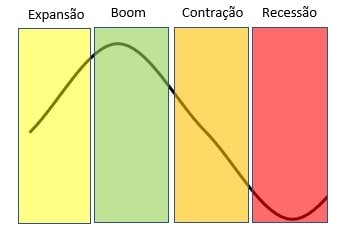

Fonte: Weinvest

Ao final de uma recessão, o movimento reinicia começando uma expansão, boom, etc. **A principal importância** de indentificar o ciclo surge exatamente dessa intuição gráfica. Podemos elencar algumas perguntas que ficam ao imaginário do leitor: Qual decisão econômica devemos tomar se identificarmos que estamos no Boom? E se estivermos na recessão, esta decisão muda?

Uma série temporal é composta por ciclo-tendência, sazonalidade e irregularidades. Para fazer previsões utlizando os métodos de série temporal, é necessário a remoção das flutuações que “contaminam” o verdadeiro comportamento da série.

Um bom filtro é capaz de remover as raízes unitárias e o componente cíclico, em outras palavras, ser capaz de isolar as flutuações dos dados em frequências pré-determinadas.

Naturalmente, ao aplicar um filtro, seremos capazes de isolar o componente cíclico da série. Para o nosso caso, estamos interessados na mensuração dos **Cíclos de Negócio** do Brasil. Para isto, faremos uma introdução cronológica dos principais métodos adotados.

Neste ensaio, não iremos aprofundar na matemática e demonstração das técnicas, todavia, todos os trabalhos seminais estão devidamente referenciados para que os interessados possam consultar.

## Instalação e Imports

```r
#install.packages("tidyverse")
#install.packages("skimr")
#install.packages("janitor")
#install.packages('seasonal')
#install.packages('gridExtra')
#install.packages('imputeTS')
#install.packages('tsoutliers')
#install.packages('forecast')
#install.packages('MASS')
#install.packages('tseries')
#install.packages("urca")
#install.packages("zoo")
#install.packages("KFAS")
#install.packages("TTR")
#install.packages("mFilter")
#install.packages("quantmod")
```

```r
# Pacote para análise de dado
library(tidyverse)

# Pacotes para limpeza e sumarização de dados
library(skimr)
library(janitor)
library(imputeTS)
library(tsoutliers)

# Dataviz
library(ggplot2)
library(scales)
library(gridExtra)
library(quantmod)

# Maniplação de datas
library(zoo)

# Série Temporal
library(seasonal)
library(stats)
library(forecast)
library(MASS) # BoxCox

# Testes de estacionariedade
library(tseries) # ADF, PP e KPSS
library(urca) # ERS

# Filtragens
library(KFAS) # Kalman
library(mFilter) # HP

# Méidas móvel
library(TTR)


# Configuração número científico
options(scipen = 999)
```

## Carregamento dos dados

```r
# Data loading
pib = read.csv("C:/Users/Macaubas/Desktop/Mestrado/Cadeiras/Series/Projeto/Series Temporal/Dados/pib_trimestral_brasil.csv", sep = ',') %>%
  rename(data = ï..data)  %>%
  dplyr::select(data, pib) %>%
  as_tibble()

# Ajustando coluna de datas
pib = pib %>%
  mutate(data = as.Date(as.yearqtr(format(data), "%Y T%q")))

# Visualizando os dados
pib
```

```
## # A tibble: 104 x 2
##    data           pib
##    <date>       <dbl>
##  1 1996-01-01 189323.
##  2 1996-04-01 204611.
##  3 1996-07-01 221513.
##  4 1996-10-01 239316.
##  5 1997-01-01 219117.
##  6 1997-04-01 232890.
##  7 1997-07-01 246178.
##  8 1997-10-01 253904.
##  9 1998-01-01 235701.
## 10 1998-04-01 251936.
## # ... with 94 more rows
```

## Estatísticas desctriva

```r
skim(pib$pib)
```

Data summary

| Name | pib$pib |
| --- | --- |
| Number of rows | 104 |
| Number of columns | 1 |
| _______________________ |  |
| Column type frequency: |  |
| numeric | 1 |
| ________________________ |  |
| Group variables | None |

**Variable type: numeric**

| skim_variable | n_missing | complete_rate | mean | sd | p0 | p25 | p50 | p75 | p100 | hist |
| --- | --- | --- | --- | --- | --- | --- | --- | --- | --- | --- |
| data | 0 | 1 | 950941.6 | 607464.3 | 189323.3 | 376686.6 | 808090 | 1502258 | 2257747 | ▇▃▂▃▂ |

## Criando série Temporal

```r
serie_pib = ts(start = c(1996,01,01),
                    pib$pib,
                    freq = 4)

tail(serie_pib, 20)
```

```
##         Qtr1    Qtr2    Qtr3    Qtr4
## 2017 1585806 1630853 1648635 1720185
## 2018 1681579 1733663 1767874 1821026
## 2019 1759313 1828764 1880632 1920422
## 2020 1845561 1722448 1888242 2011364
## 2021 2065955 2140603 2215185 2257747
```

## Filtros

### Kalman

**Preparando para filtro kalman**

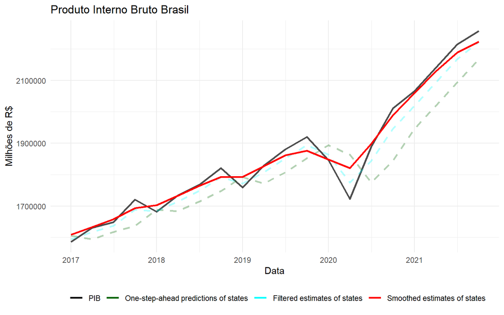

```r
kalman = pib %>%
  mutate(log_pib = log(pib)) # Log natural

log_model = SSModel(kalman$log_pib ~ SSMtrend(1, Q = 0.01), H = 0.01)

resul_kalman = KFS(log_model)

kalman = kalman %>%
  mutate(a = exp(resul_kalman$a[1:104]),
         att = exp(resul_kalman$att),
         alpha = exp(resul_kalman$alpha))

kalman %>%
  filter(data >= "2017-01-01") %>%
  ggplot(aes(x = data)) +
  geom_line(aes(y = pib, colour = 'PIB'), size = 1,
            alpha = .7) +
  geom_line(aes(y = a, colour = 'One-step-ahead predictions of states'), size = 1,
            alpha = 0.3,
            linetype="dashed") +
  geom_line(aes(y = att, colour = 'Filtered estimates of states'), size = 1,
            alpha = 0.3,
            linetype="dashed") +
  geom_line(aes(y = alpha, colour = 'Smoothed estimates of states'), size = 1,
            alpha = 1) +
  scale_color_manual(name = '', values = c('PIB' = 'black',
                                           'One-step-ahead predictions of states' = 'darkgreen',
                                           'Filtered estimates of states' = 'cyan',
                                           'Smoothed estimates of states'= 'red')) +
  labs(y = 'Milhões de R$', x = 'Data', title  = 'Produto Interno Bruto Brasil') +
  theme_minimal() +
  theme(legend.position="bottom")
```

Filtramos a série apenas para os valores após 2017 para que fique mais fácil a visualização dos valores filtrados. Percebe-se que o componente suavizado “Smoothed estimates of states” é capaz de retirar os componente irregulares.

Podemos interpretar os momentos em que a linha preta está abaixo da linha vermelha como momento de contração/recessão, e quando a linha preta está acima da linha vermelha, momentos de expansão e boom.

**O filtro de Kalman é capaz de suavizar a série para seu componente cíclico.** Além disso, podemos perceber que, de acordo com filtro de Kalman, estamos nos aproximando do estágio de Boom do ciclo econômico.

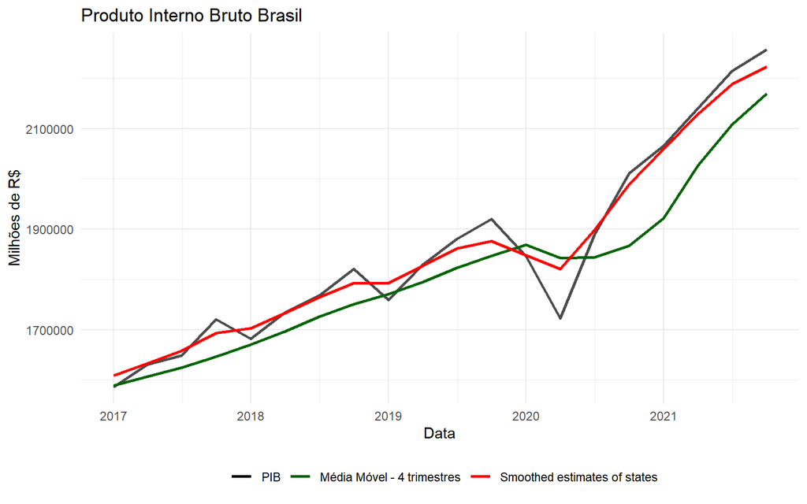

```r
kalman = kalman %>%
  mutate(mme = SMA(pib, n = 4)) %>%
  as_tibble()


kalman %>%
  filter(data >= "2017-01-01") %>%
  ggplot(aes(x = data)) +
  geom_line(aes(y = pib, colour = 'PIB'), size = 1,
            alpha = .7) +
  geom_line(aes(y = mme, colour = 'Média Móvel - 4 trimestres'), size = 1,
            alpha = 1) +
  geom_line(aes(y = alpha, colour = 'Smoothed estimates of states'), size = 1,
            alpha = 1) +
  scale_color_manual(name = '', values = c('PIB' = 'black',
                                           'Média Móvel - 4 trimestres' = 'darkgreen',
                                           'Smoothed estimates of states'= 'red')) +
  labs(y = 'Milhões de R$', x = 'Data', title = 'Produto Interno Bruto Brasil') +
  theme_minimal() +
  theme(legend.position="bottom")
```

Média móvel só é capaz de captar variações bruscas do PIB, como no caso da Covid-19. Percebe-se que os períodos de boom e recessão (picos e vales) estão subestimados. De forma geral, a média móvel é capaz de suavizar a série para esses movimentos irregulares, porém é pouco sensível a oscilações menos abruptas. Note que, de acordo com seu objetivo a média móvel pode ser uma boa solução.

## Primeira Diferença

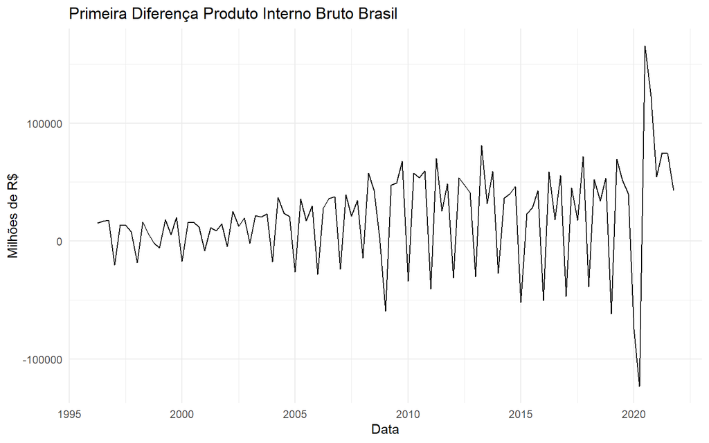

```r
primeira_diff = diff(serie_pib)

autoplot(primeira_diff) +
  labs(y = 'Milhões de R$', x = 'Data', title = 'Primeira Diferença Produto Interno Bruto Brasil') +
  theme_minimal()
```

A primeira diferença também é capaz de extrair o componente cíclico da série, percebe-se que para este caso o ciclo é bastante períodico e provavelmente estacionário - é necessário fazer os testes formais de estacionariedade para garantir esta hipótese. Por hora, podemos testar quantas diferenças são necessárias para estacionar nossa série.

```r
ndiffs(serie_pib)
```

```
## [1] 2
```

O código acima sugere a segunda diferença para estacionar nossa série, dessa forma, podemos verificar o comportamento da nossa série a partir da segunda diferença.

## Segunda Diferença

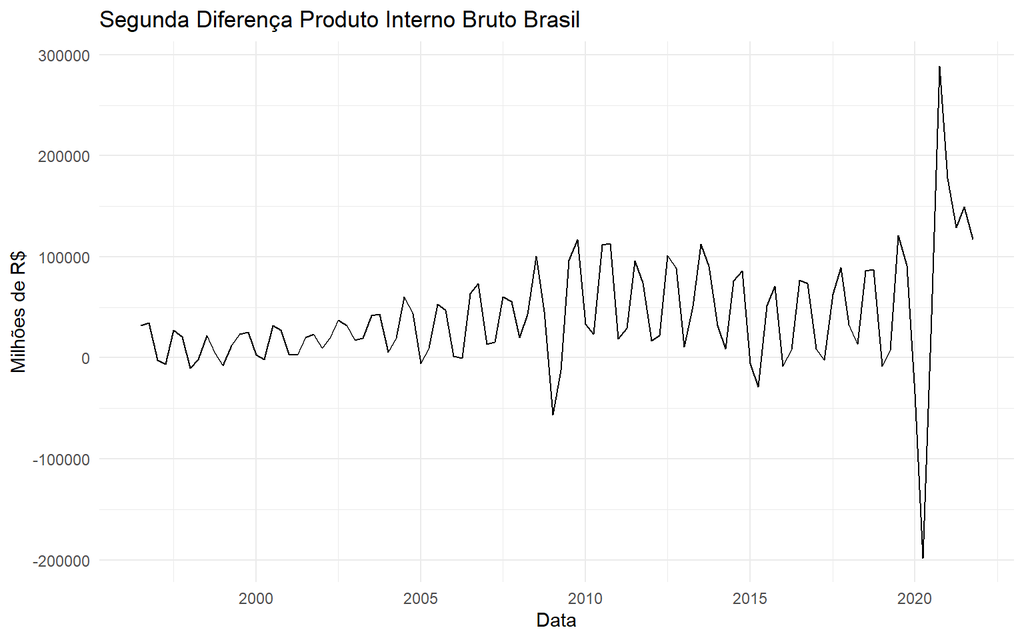

```r
segunda_diff = diff(serie_pib,2)

autoplot(segunda_diff) +
  labs(y = 'Milhões de R$', x = 'Data', title = 'Segunda Diferença Produto Interno Bruto Brasil') +
  theme_minimal()
```

Dessa forma, temos um componente cíclico bem definido e estacionário da nossa série. Veja que o esta tecnica sugere que estamos no aproximando de um período de **recessão** da economia.

## Hodrick Prescott Filter (HP Filter)

O filtro HP, o mais comum na economia, é capaz de estimar os componentes cíclico e tendência da série. Este filtro pressupõe que a tendência da série tem uma distribção aleatória e não-correlata ao componente cíclico.

Para implementá-lo, devemos atentar ao valores sugeridos para $\lambda$ de acordo com os valores estimados pelos autores:

- $\lambda = 100$ ou $\lambda = 400$, para séries anuais
- $\lambda = 1600$, para séries trimestrais
- $\lambda = 14400$, para séries mensais

Dado que estamos trabalhando com o PIB trimestral do Brasil, iremos adotadar **$\lambda = 1600$**. Partindo do pressuposto que este o valor correto, iremos demonstrar como diferentes lambda podem afetar a estimação dos componentes.

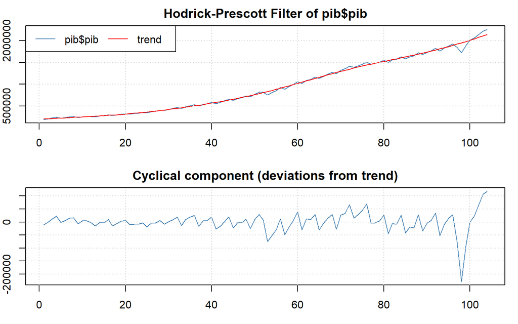

```r
hpf = hpfilter(pib$pib, freq = 1600)

plot(hpf)
```

Similarmente ao filtro de Kalman, o filtro **HP sugere, pelo componente cíclico estimado, que já estamos nos aproximando de um momento de Boom**, indicando que a economia estará entrando em seu estágio de recessão em um futuro próximo.

## Baxter-King (BK Filter)

No filtro BK, os autores entendem que os demais método de suavização são *ad hoc*, pois não há controle sob a definição dos filtros. Em decorrência, o filtro BK adicionará um controle *band-pass* sob a técnica de filtragem.

O filtro eliminará o componente de tendência e irregular, restando o componente intermediário que é o ciclo. De forma simplificada podemos assumir três tipos de frequências em uma série:

- Frequência baixa - Tendência
- Frequência alta - Irregular
- Frequência intermediária - Ciclo
  - Entende-se como frequência intermediária tudo entre a baixa frequência e alta frequência.

### BK Filter ajustado para ciclos de Kitchin

Neste primeiro momento, ajustaremos o filtro de Baxter-King para o ciclo de Kitchin (3 - 4 anos).

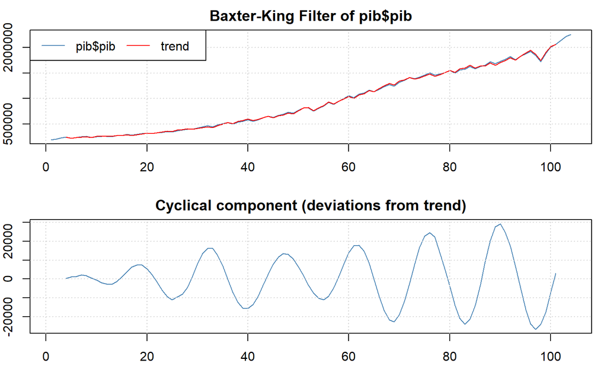

```r
bkf_kitchin = bkfilter(pib$pib, pl = 12, pu = 16, type = "variable")

plot(bkf_kitchin)
```

Por esta abordagem é possível perceber que o filtro **Baxter-King indica que estamos em um estágio de expansão**, porém não há indicações de inflexão no do ciclo. Dito isto, não podemos inferir se estamos chegando a o fim da fase de expansão.

### BK Filter ajustado para ciclos de Juglar

Alternativamente, ajustaremos o filtro de Baxter-King para o ciclo de Juglar (7 - 10 anos).

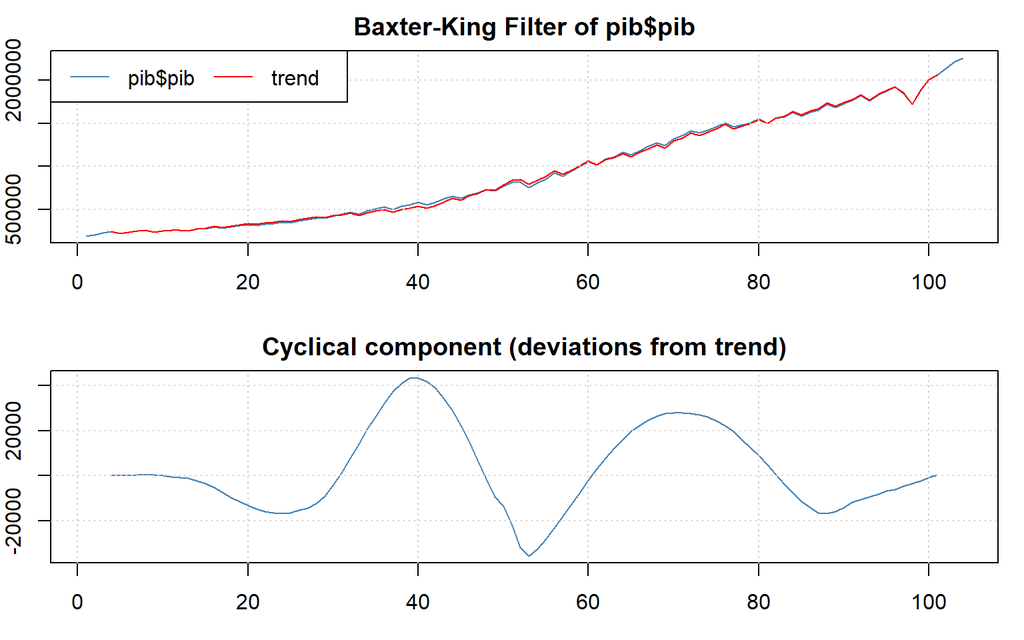

```r
bkf_juglar = bkfilter(pib$pib, pl = 28, pu = 40, type = "variable")

plot(bkf_juglar)
```

Podemos verificar que por esta abordagem teórica alternativa, o componente cíclico extraído por BK **sugere que estamos nos aproximando do estágio de Boom**. Novamente, não há qualquer indicativo de inflexão do componente cíclico do PIB.

## Christiano Fitzgerald (CF Filter)

Similar ao filtro BK, o filtro CF também opera sob condições de *band-pass* ideal, permitindo um maior controle sob a definição do ciclo. Enquanto o filtro BK assume um comportamento simétrico da média móvel para aproximar o band-pass, o filtro CF assume que a série segue um comportamento aleatório sem drift.

**Não ajustamos o filtro BK para outros tipo de definições de ciclo dado a limitação de observações dos dados**

### CF filter - ajustado para ciclo de Kitchin

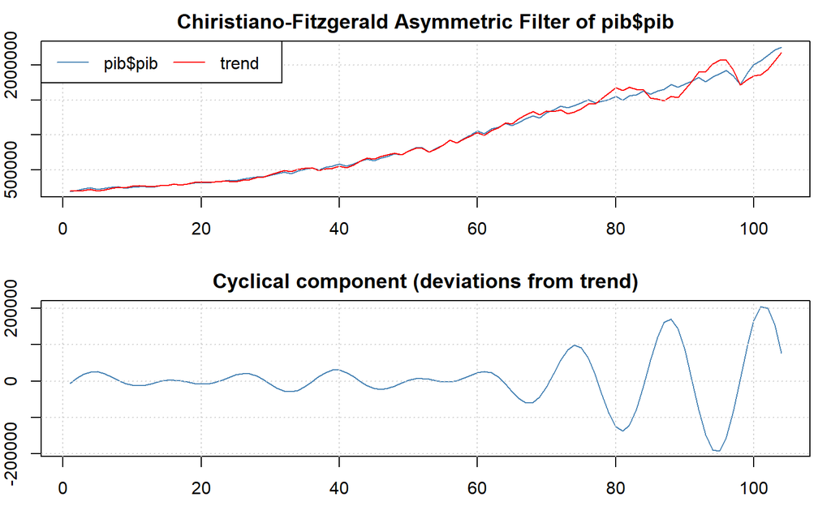

```r
cff_kitchin = cffilter(pib$pib, pl = 12, pu = 16)

plot(cff_kitchin)
```

Diferente do filtro BK, o componente cíclico do **filtro CF capta que estamos nos aproximando do momento de contração do ciclo econômico**, onde já é possível perceber uma inflexão da curva.

### CF filter - ajustado para ciclo de Juglar

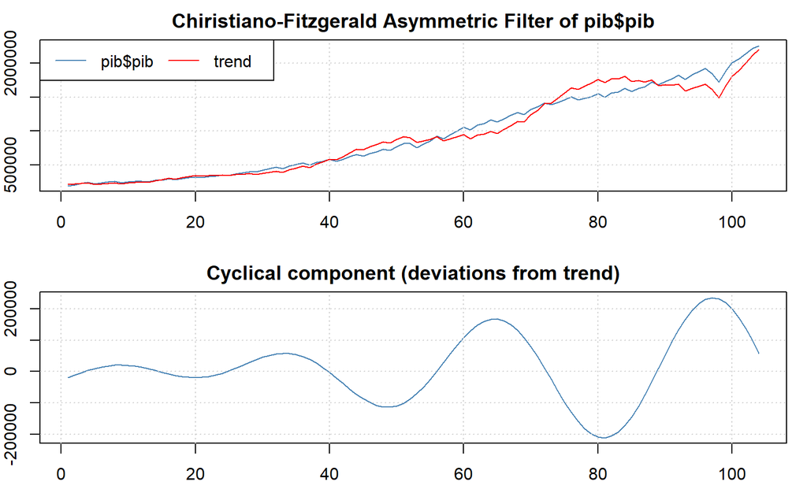

```r
cff_juglar = cffilter(pib$pib, pl = 28, pu = 40)

plot(cff_juglar)
```

Por sua vez, o filtro CF ajustado para os ciclos de Juglar indica que estamos começando um movimento de **arrefecimento do ciclo econômico - estágio de contração**.

## HP, BK e CF

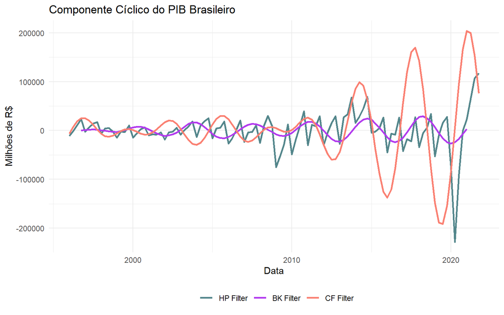

```r
ciclos = data.frame(pib$data, hpf$cycle, bkf_kitchin$cycle, cff_kitchin$cycle)

ciclos %>%
  ggplot(aes(x = pib.data)) +
  geom_line(aes(y = hpf.cycle, colour = 'HP Filter'), size = 1) +
  geom_line(aes(y = bkf_kitchin.cycle, colour = 'BK Filter'), size = 1) +
  geom_line(aes(y =  cff_kitchin.cycle, colour = 'CF Filter'), size = 1) +
  scale_color_manual(name = '', values = c('HP Filter' = 'cadetblue4',
                                           'BK Filter' = 'darkorchid2',
                                           'CF Filter'= 'salmon')) +
  labs(y = 'Milhões de R$', x = 'Data', title = 'Componente Cíclico do PIB Brasileiro') +
  theme_minimal() +
  theme(legend.position="bottom")
```

Desta forma é perceptível identificar as diferenças no comportamento do ciclo de acordo com a técnica e calibração dos modelos adotados. Há momentos em que o HP mensura dois ciclos completos, enquanto o CF identifica apenas um. Por sua vez, o filtro BK é menos sensível a variações de curtíssimo prazo. Os filtros CF e HP são capazes de captar uma maior intensidade dos ciclos desde o ano de 2012, enquanto o BK parece não reagir a este cenário.

Vale mais uma vez enfatizar que os filtros BK e CF possuem restrições de *band-pass*, por isso que há diferenças consideráveis nos ciclos captados.

## Considerações Finais

Os ciclos econômicos são importante aspecto da atividade econômica do país, indentificar em qual estágio do ciclo estamos permite uma maior precisão na decisão dos agentes econômicos (públicos e privados). Existem diversas formas de captar o componente ciclo das séries, filtros seminais não permitem o controle da definição dos períodos dos ciclos - MME, Kalman, Primeira Diferença, HP.

Por sua vez, filtros mais recentes como BK e CF permitem um maior controle do pesquisador em relação aos ciclos. Por um lado, estes últimos são mais flexíveis a diferentes referenciais teóricos da definição da periodicidade dos ciclos, por outro, há diferentes interpretações da duração do ciclo podem afetar os resultados da estimação dos ciclos e comprometer a análise do cientista.

Não há forma certa ou errada de decompor uma série, porém, deve-se ter cuidado com a calibração correta dos modelos - principalmente do fator $\lambda$ do filtro HP. Diferentes técnicas resultaram em diferentes resultados, cabendo a cautela teórica do pesquisador para interpretar seus resultados.

## Referências

### Filtros

KALMAN, Rudolph Emil. **A new approach to linear filtering and prediction problems**. 1960.

HODRICK, Robert J.; PRESCOTT, Edward C. **Postwar US business cycles: an empirical investigation**. Journal of Money, credit, and Banking, p. 1-16, 1997.

BAXTER, Marianne; KING, Robert G. **Measuring business cycles: approximate band-pass filters for economic time series**. Review of economics and statistics, v. 81, n. 4, p. 575-593, 1999.

CHRISTIANO, Lawrence J.; FITZGERALD, Terry J. The band pass filter. international economic review, v. 44, n. 2, p. 435-465, 2003.

### Ciclo Econômicos

KOROTAYEV, Andrey V.; TSIREL, Sergey V. A spectral analysis of world GDP dynamics: Kondratieff waves, Kuznets swings, Juglar and Kitchin cycles in global economic development, and the 2008–2009 economic crisis. **Structure and Dynamics**, v. 4, n. 1, 2010.

### Sítios

[India Analytics Magazine](https://analyticsindiamag.com/a-complete-tutorial-on-time-series-filters/)

[Data Science Plus](https://datascienceplus.com/kalman-filter-modelling-time-series-shocks-with-kfas-in-r/)